# Coursera Statistical Inference Course Project Part_1

ZiadAbdelnabi

7/4/2020

## Overview

In part 1 of this project we are investigating the exponential distribution in R and comparing it with the Central Limit Theorem using a simulation exercise.

## Part 1: Simulation Exercise

### 1.1 Show the sample mean and compare it to the theoretical mean of the distribution.

As per the instructions, the exponential distribution can be simulated in R with the function rexp(n, lambda) where lambda is the rate parameter. The simulation can be repeated multiple times using the repetition function.

The theoretical mean of exponential distribution is 1/lambda and the standard deviation is also 1/lambda.

For the 1000 simulations, lambda is assumed to be 0.2 and the sample size n is 40.

```r
n <- 40
Simulations <- 1000
Lambda <- 0.2

SampleMean <- NULL
for(i in 1:Simulations) {
  SampleMean <- c(SampleMean, mean(rexp(n, Lambda)))
}
mean(SampleMean)
```

```
## [1] 5.000089
```

So, as we can see, compared to the theoretical mean distribution of 5 , our mean 5 is close.

### 1.2 Show how variable the sample is (via variance) and compare it to the theoretical variance of the distribution.

The theoretical standard deviation of the distribution is also 1/lambda , which, for a lambda of 0.2 , equates to 5 . The variance is the square of the standard deviation, which is 25 .

```r
Variance <- var(SampleMean)
Variance
```

```
## [1] 0.6417125
```

### 1.3 Show that the distribution is approximately normal.

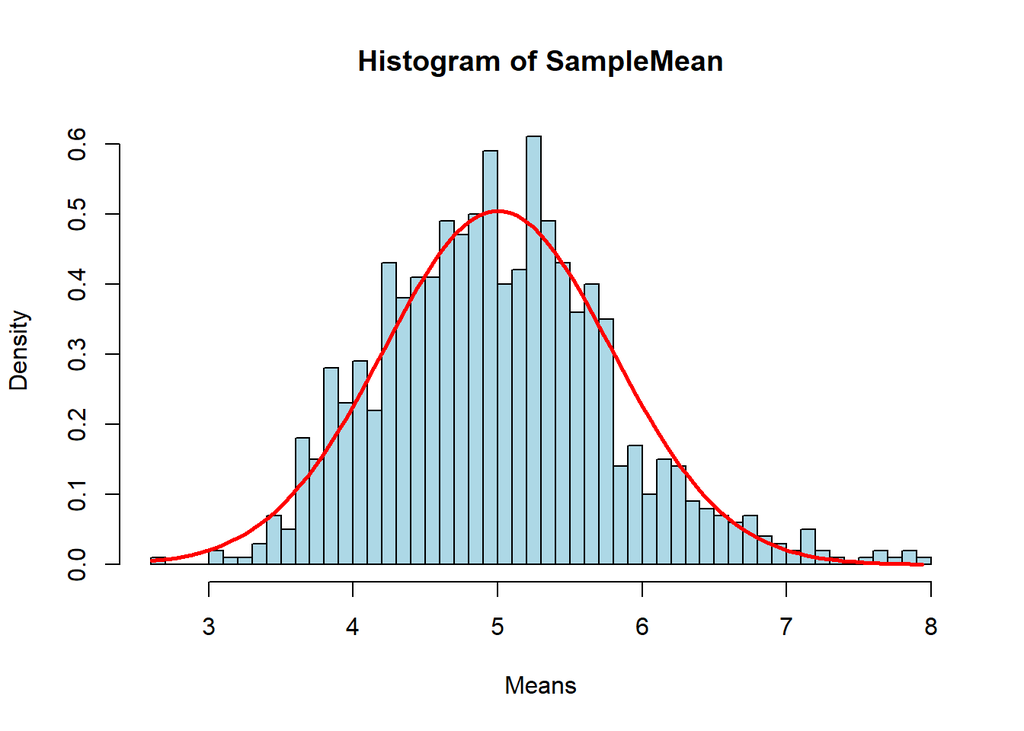

```r
hist(SampleMean, breaks = n, prob = T, col = "light blue", xlab = "Means")
x <- seq(min(SampleMean), max(SampleMean), length = 100)
lines(x, dnorm(x, mean = 1/Lambda, sd = (1/Lambda/sqrt(n))), pch = 25, col = "red", lty=1, lwd=2.5)
```

The central limit theorom states that the sample means would become that of a standard normal distribution as the sample size increases whilst meeting the two conditions of independence ( n < 10% ) and normal, or if skewed distribution, that n > 30.